# CEE218X Assignment 1

## 1.1

*Create bar or line charts showing monthly total kBTUs of residential and commercial electricity and gas consumption for the Bay Area (meaning the sum of all ZIP codes in the 9 Bay Area counties) from 2017 to the latest available month.*

```r
library(tidyverse)
library(sf)
library(tigris)
library(leaflet)
library(plotly)

# Download data
years <- 2017:2020
quarters <- 1:4
type <- "Electric"
pge_elec <- NULL

for(year in years){
  for(quarter in quarters) {
    if(year == 2020 && quarter %in% 3:4){
      next()
    }
    filename <-
      paste0(
        "pge/PGE_",
        year,
        "_Q",
        quarter,
        "_",
        type,
        "UsageByZip.csv"
      )

    print(filename)
    temp <- read_csv(filename)
    pge_elec <- rbind(pge_elec,temp)
    saveRDS(pge_elec, "pge_elec.rds")
  }
}
years <- 2017:2020
quarters <- 1:4
type <- "Gas"
pge_gas <- NULL

# Manipulate data
for(year in years){
  for(quarter in quarters) {
    if(year == 2020 && quarter %in% 3:4){
      next()
    }
    filename <-
      paste0(
        "pge/PGE_",
        year,
        "_Q",
        quarter,
        "_",
        type,
        "UsageByZip.csv"
      )
    print(filename)
    temp <- read_csv(filename)
    pge_gas <- rbind(pge_gas,temp)
    saveRDS(pge_gas, "pge_gas.rds")
}
}
pge_elec$TOTALKBTU <- 3.412 * pge_elec$TOTALKWH
pge_gas$TOTALKBTU <- 100 * pge_gas$TOTALTHM
names(pge_gas)
pge_elec$AVERAGEKWH <- NULL
pge_elec$TOTALKWH <- NULL
pge_gas$TOTALTHM <- NULL
pge_gas$AVERAGETHM <- NULL
pge_total <- rbind(pge_elec, pge_gas)
```

```r
ca_counties <- counties("06", cb = T, progress_bar = F)
bay_county_names <-
  c(
    "Alameda",
    "Contra Costa",
    "Marin",
    "Napa",
    "San Francisco",
    "San Mateo",
    "Santa Clara",
    "Solano",
    "Sonoma"
  )
bay_counties <-
  ca_counties %>%
  filter(NAME %in% bay_county_names)
usa_zips <-
  zctas(cb = T, progress_bar = F)
bay_zips <-
  usa_zips %>%
  st_centroid() %>%
  .[bay_counties, ] %>%
  st_set_geometry(NULL) %>%
  left_join(usa_zips %>% select(GEOID10)) %>%
  st_as_sf()
```

```r
pge_final <-
  pge_total %>%
  filter(CUSTOMERCLASS %in%
      c(
        "Elec- Residential",
        "Elec- Commercial",
        "Gas- Residential",
        "Gas- Commercial"
      ),
  ZIPCODE %in% bay_zips$GEOID10
)
pge_group <-
  group_by(
    pge_final,
    MONTH,
    YEAR,
    CUSTOMERCLASS
  )

pge_summarize <-
  summarize(
    pge_group,
    TOTALKBTU =
      sum(
        TOTALKBTU,
        na.rm = T
      )
  )
pge_summarize$DATE <- as.Date(paste(pge_summarize$YEAR, pge_summarize$MONTH, "01", sep = "-"))
```

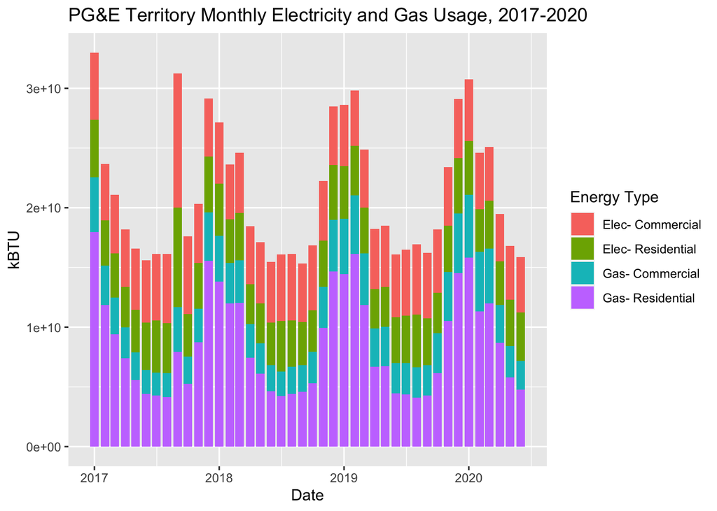

```r
pge_chart <-
  pge_summarize %>%
  ggplot() +
  geom_bar(
    aes(
      x = DATE,
      y = TOTALKBTU,
      fill = CUSTOMERCLASS
    ),
    stat = "identity",
    position = "stack"
  ) +
  labs(
    x = "Date",
    y = "kBTU",
    title = "PG&E Territory Monthly Electricity and Gas Usage, 2017-2020",
    fill = "Energy Type"
  )
pge_chart
```

From this bar chart we could see that electricity consumption in commercial from April to June 2020 (shelter-in-place period) are smaller than previous years’ consumption. One possible explanation is the large percentage of stores were closed due to related orders.

## 1.2

*Create at least one map that highlights which neighborhoods experienced the greatest change in electricity consumption before and after the pandemic began, and comment on your results. Explain any key assumptions you made in the analysis, or caveats about the data sources that you think the reader should be aware of.*

```r
pge_covid_change_res <-
  pge_final %>%
  filter(
    YEAR %in% (2019:2020),
    MONTH %in% (4:6),
    CUSTOMERCLASS == "Elec- Residential") %>%
  group_by(ZIPCODE, YEAR) %>%
  summarize(
    TOTALKBTU =
      sum(
        TOTALKBTU,
        na.rm = T)
  ) %>%
  pivot_wider(
    names_from = YEAR,
    values_from = TOTALKBTU
  ) %>%
  rename(KBTU2019 = "2019", KBTU2020 = "2020") %>%
  mutate(
    Change = (KBTU2020-KBTU2019)
  ) %>%
  drop_na()
```

```r
pge_covid_change_geo_res <-
  pge_covid_change_res %>%
  mutate(
      ZIPCODE = ZIPCODE %>% as.character()
    ) %>%
  right_join(
    bay_zips %>% select(GEOID10),
    by = c("ZIPCODE" = "GEOID10")
  ) %>%
  drop_na() %>%
  st_as_sf() %>%
  st_transform(4326)
```

```r
#CREATE MAP
res_pal <- colorNumeric(
  palette = "Spectral",
  domain = pge_covid_change_geo_res$Change
)
leaflet() %>%
  addTiles() %>%
  addPolygons(
    data = pge_covid_change_geo_res,
    fillColor = ~res_pal(Change),
    color = "black",
    opacity = 0.5,
    fillOpacity = 0.5,
    weight = 1,
    label = ~paste0(
      round(Change),
      " kBTU Change in Residential Electricity from April-June 2019 to 2020 in Zipcode: ",
      ZIPCODE
    ),
    highlightOptions = highlightOptions(
      weight = 2,
      opacity = 1
    )
  ) %>%
  addLegend(
    data = pge_covid_change_geo_res,
    pal = res_pal,
    values = ~Change,
    title = "Change in Residential Electricity Usage<br> During COVID-19"
  )
```

[interactive chart not shown]

This map visualizes the change in residential energy usage during Covid-19 in the bay area. Specifically, it compares the residential electricity usage between April to June in 2019 and 2020. Warm colors indicate usage decrease from 2019 to 2020 while colors mean otherwise. We could see the majority of Zip-code areas endure an increase in residential electricity usage. In addition, zip-code 94612 in Oakland has the most significant electricity usage decrease, while 94565 in Pittsburg has the biggest increase.

```r
pge_covid_change_com <-
  pge_final %>%
  filter(
    YEAR %in% (2019:2020),
    MONTH %in% (4:6),
    CUSTOMERCLASS == "Elec- Commercial") %>%
  group_by(ZIPCODE, YEAR) %>%
  summarize(
    TOTALKBTU =
      sum(
        TOTALKBTU,
        na.rm = T)
  ) %>%
  pivot_wider(
    names_from = YEAR,
    values_from = TOTALKBTU
  ) %>%
  rename(KBTU2019 = "2019", KBTU2020 = "2020") %>%
  mutate(
    Change = (KBTU2020-KBTU2019)
  ) %>%
  drop_na()
```

```r
pge_covid_change_geo_com <-
  pge_covid_change_com %>%
  mutate(
      ZIPCODE = ZIPCODE %>% as.character()
    ) %>%
  right_join(
    bay_zips %>% select(GEOID10),
    by = c("ZIPCODE" = "GEOID10")
  ) %>%
  drop_na() %>%
  st_as_sf() %>%
  st_transform(4326)
```

```r
#CREATE MAP
com_pal <- colorNumeric(
  palette = "Spectral",
  domain = pge_covid_change_geo_com$Change
)
leaflet() %>%
  addTiles() %>%
  addPolygons(
    data = pge_covid_change_geo_com,
    fillColor = ~com_pal(Change),
    color = "black",
    opacity = 0.5,
    fillOpacity = 0.5,
    weight = 1,
    label = ~paste0(
      round(Change),
      " kBTU Change in Commercial Electricity from April-June 2019 to 2020 in Zipcode: ",
      ZIPCODE
    ),
    highlightOptions = highlightOptions(
      weight = 2,
      opacity = 1
    )
  ) %>%
  addLegend(
    data = pge_covid_change_geo_com,
    pal = com_pal,
    values = ~Change,
    title = "Change in Commercial Electricity Usage<br> During COVID-19"
  )
```

[interactive chart not shown]

This map visualizes the change in commercial energy usage during Covid-19 in the bay area. Specifically, it compares the commercial electricity usage between April to June in 2019 and 2020. Warm colors indicate usage decrease from 2019 to 2020 while colors mean otherwise. We could see the majority of Zip-code areas endure a decrease in commercial electricity usage. For example, zip-code 94043 in Mountain View has a significant electricity usage decrease, one possible explanation could be the shutdown of office spaces in the area.